# Data Quality Assessment

Matthias Templ[^1]

Barbara Templ[^2]

2026-04-23

*Vignette 2 of 4 for the **pep725** R package. The most current version is available on [GitHub](https://github.com/matthias-da/pep725) and [CRAN](https://CRAN.R-project.org/package=pep725).*

## Introduction

Data quality assessment is a critical but often overlooked step in phenological analysis. Before calculating trends, normals, or climate sensitivities, you need to understand what’s in your data and make informed decisions about unusual observations.

### The Data Quality Challenge

Long-term phenological datasets such as PEP725 are compiled from many observers over decades. This richness enables large-scale analyses, but it also introduces data quality challenges that need to be assessed:

| Issue Type | Examples | Consequence if Ignored |
| --- | --- | --- |
| **Recording errors** | Typographical errors (DOY 150 instead of 105), incorrect year | Outliers bias statistics |
| **Identification errors** | Confusion between morphologically similar species | Inconsistent or mixed time series |
| **Protocol changes** | Changes in the definition of phenological phases over time | Artificial shifts or trends |
| **Biological anomalies** | Irregular phenological events as a result of climate extremes | May represent real biological signals |

The following sections introduce practical tools in pep725 package for diagnosing and handling these issues in a transparent and reproducible way.

### What You’ll Learn

| Section | Topic | Key Functions |
| --- | --- | --- |
| Part 1 | Detecting statistical outliers | `pep_flag_outliers()`, `pep_plot_outliers()` |
| Part 2 | Temporal coverage and completeness | `pep_completeness()` |
| Part 3 | Phase presence validation | `pep_check_phases()` |
| Part 4 | Integrated workflow | Combining all approaches |

### Prerequisites

This vignette assumes you are familiar with:

- Basic phenological concepts (from “Getting Started” vignette)
- Day of Year (DOY) as a timing metric
- BBCH phenological phase codes

## Setup

```r
library(pep725)
library(data.table)

# Download the synthetic dataset
pep <- pep_download()

# For this vignette, we'll focus on flowering phases
flowering <- pep[phase_id %in% c(60, 65)]
cat("Flowering observations:", nrow(flowering), "\n")
```

```
#> Flowering observations: 1310094
```

```r
cat("Species:", length(unique(flowering$species)), "\n")
```

```
#> Species: 36
```

```r
cat("Year range:", min(flowering$year), "-", max(flowering$year), "\n")
```

```
#> Year range: 1868 - 2025
```

# Part 1: Outlier Detection

## Why Detect Outliers?

An **outlier** is an observation that differs substantially from the expected pattern. In phenological data, outliers may indicate:

1. **Recording errors** that should be excluded from analysis
   - A typo: DOY 250 instead of DOY 150 (roughly 3 months difference)
   - Wrong year entered: observation assigned to incorrect season
2. **Unusual weather events** worth investigating
   - Very warm winter causing early flowering
   - Late frost delaying spring phenology
3. **Second flowering** or other abnormal phenological events
   - Plants flowering again in autumn/winter after spring flowering
   - Increasingly observed with climate change

**The challenge**: You can’t simply delete all outliers. Some are errors, but others are scientifically valuable observations of unusual events.

## Statistical Methods for Outlier Detection

### Method 1: 30-Day Rule (Simple Threshold)

The simplest approach: flag any observation more than 30 days from the median for that species/phase combination.

```r
# Flag outliers using the default 30-day rule
outliers <- pep_flag_outliers(
  pep = flowering,
  method = "30day",
  by = c("species", "phase_id")
)

print(outliers)
```

```
#> Phenological Outlier Detection Results
#> =============================================
#> Method: 30day
#> Threshold: 30 days
#> Grouping: species, phase_id
#>
#> Total observations: 1,310,094
#> Outliers flagged: 26573 (2.03%)
#>   - Early outliers: 15011
#>   - Late outliers: 11562
#>
#> Deviation summary for outliers:
#>   Min: -167.0 days
#>   Max: 223.0 days
#>   Mean |deviation|: 38.4 days
```

**How it works:**

```
                     Distribution of flowering dates

        ← Early                                    Late →

   ----|----[=======|=======]----|-----
        ^           ^           ^
     -30 days    median      +30 days

   Anything outside the brackets is flagged as an outlier
```

### Understanding the Output

The function adds new columns to your original data:

| Column | What It Contains | How to Use It |
| --- | --- | --- |
| `is_outlier` | TRUE/FALSE flag | Filter data: `data[is_outlier == FALSE]` |
| `deviation` | Days from expected | Prioritize investigation: larger = more extreme |
| `expected_doy` | Reference DOY (median) | Understand what “normal” looks like |

### Method 2: MAD (Median Absolute Deviation) - Recommended

The MAD method is **robust to the presence of multiple outliers**. This is important because if your data contains many outliers, they can distort mean-based methods.

```r
# MAD method: flag if > 3 MAD from median (robust)
outliers_mad <- pep_flag_outliers(flowering, method = "mad", threshold = 3)
```

**Why MAD is recommended:**

| Scenario | Mean-based method | MAD method |
| --- | --- | --- |
| 1-2 outliers | Works reasonably | Works well |
| Many outliers | Outliers inflate SD, may miss more | Stays robust |
| Asymmetric data | Assumes symmetry | Handles asymmetry |

### Method 3: IQR (Interquartile Range) - Also Robust

The IQR method uses quartiles and is familiar from boxplot “whiskers”:

```r
# IQR method: flag if outside 1.5 * IQR (standard boxplot rule)
outliers_iqr <- pep_flag_outliers(flowering, method = "iqr", threshold = 1.5)
```

**How it works:** - Q1 = 25th percentile, Q3 = 75th percentile - IQR = Q3 - Q1 - Outlier if: value < Q1 - 1.5×IQR OR value > Q3 + 1.5×IQR

### Method 4: Z-Score - Sensitive but Less Robust

The z-score method assumes normally distributed data:

```r
# Z-score method: flag if |z| > 3 (assumes normal distribution)
outliers_zscore <- pep_flag_outliers(flowering, method = "zscore", threshold = 3)
```

**Caution**: The z-score method is sensitive to existing outliers. If your data has many outliers, they will inflate the standard deviation, making the z-score threshold less effective at detecting them.

### Method 5: GAM Residual - Model-based, Covariate-aware

The four methods above are all **univariate within a group** — they compare each observation to the central tendency of its own station-species-phase combination. That misses three realistic outlier patterns:

1. **Year-effect outliers.** In a year where most of central Europe bloomed 8 days earlier, a station that flowered on its 30-year median looks “late” only because the reference ignores the shared weather signal.
2. **Covariate-inconsistent reports.** A lowland station that reports a DOY typical of a mountain station is invisible to a within-station detector because the station’s own history may be short.
3. **Trend-inconsistent reports.** A station whose DOY is constant while every other station in the network has a trend is anomalous only in relation to the trend.

`method = "gam_residual"` tackles all three. For each group (typically species × phase), it fits a GAM of DOY on year, altitude, latitude, and a station random intercept (customisable via `formula =`) and flags observations whose residual — standardised by a robust MAD scale — exceeds the threshold:

```r
# Model-based detection across the whole species x phase group.
outliers_gam <- pep_flag_outliers(
  apple_flowering,
  by = c("genus", "species", "phase_id"),
  method = "gam_residual",
  threshold = 3.5
)
```

The `deviation` column now holds GAM residuals in days (not deviations from a within-station median), and `expected_doy` holds the fitted values — so the station-year whose residual is 20 days above the fit is flagged whether or not its station’s history made that value look “normal”.

Groups with fewer observations than `min_n_per_group` (default 50) or where the GAM fails to converge silently fall back to the 30-day rule.

### Method 6: Mahalanobis - Multivariate, Robust (MCD)

All methods above flag observations one at a time. A station-year could have an entirely reasonable BBCH 60 date and an entirely reasonable BBCH 65 date, but only **one day apart** — biologically impossible, because first flowering precedes full flowering by ~10 days.

`method = "mahalanobis"` catches this by treating each station-year as a *vector* across phases and computing the **robust Mahalanobis distance** of that vector from the centre of the rest of the network. “Robust” matters: the classical Mahalanobis distance uses the sample mean and covariance, which are themselves pulled by outliers (masking). We use the **Minimum Covariance Determinant** estimator (Rousseeuw 1984, `robustbase::covMcd()`) which gives a high-breakdown robust centre and scatter, so the outliers stay *outside* the robust ellipsoid instead of contaminating it:

```r
# Multivariate detection on the phase profile per station-year.
# by = c("genus", "species") pools across phases so the covariance
# is estimated from the joint (BBCH 60, BBCH 65, BBCH 89) distribution.
outliers_mahal <- pep_flag_outliers(
  apple,
  by = c("genus", "species"),
  method = "mahalanobis"
)
```

The default threshold is `sqrt(qchisq(0.975, df = p))` where *p* is the number of phases — the standard chi-square containment cut-off under multivariate normality. Flagged station-years get all their phase rows marked; `deviation` stores the robust MD (not a day-count, so it is unitless).

### Choosing a Method

| Method | Best For | Threshold Meaning |
| --- | --- | --- |
| `30day` | Simple, interpretable threshold | Absolute days from median |
| `mad` | Most situations (recommended for single-phase) | Number of MADs from median |
| `iqr` | Familiar boxplot-style detection | IQR multiplier |
| `zscore` | Clean data, normal distribution | Standard deviations |
| `gam_residual` | Year / elevation / station covariates available | Robust z on GAM residuals |
| `mahalanobis` | Multiple phases per station-year | `sqrt(chi^2_{0.975, p})` default |

### Summary Statistics

```r
summary(outliers)
```

```
#> Phenological Outlier Summary
#> =============================================
#>
#> Total observations: 1,310,094
#> Total outliers: 26573 (2.03%)
#>
#> Groups with most outliers:
#>               species phase_id  n_obs n_outliers pct_outliers mean_dev
#>                <fctr>    <int>  <int>      <int>        <num>    <num>
#>  1: Solanum tuberosum       60 114245       6420         5.62     12.0
#>  2:  Prunus domestica       60 114641       2958         2.58     10.5
#>  3:  Prunus domestica       65  77393       2146         2.77     10.8
#>  4:   Malus domestica       60 205403       1957         0.95      9.1
#>  5:   Malus domestica       65 175706       1770         1.01      9.1
#>  6:    Prunus persica       60  48074       1515         3.15     11.0
#>  7:    Prunus cerasus       60 136588       1227         0.90      9.0
#>  8:    Prunus cerasus       65 112597       1042         0.93      9.0
#>  9:  Prunus armeniaca       60  22692        943         4.16     12.1
#> 10:    Pyrus communis       60  50335        940         1.87      9.5
#>
#> Deviation distribution (all data):
#>  1%  5% 25% 50% 75% 95% 99%
#> -31 -21  -8   0   8  20  30
```

### Comparing Outlier Rates Across Species

Different species may have different outlier rates due to observation difficulty or data quality:

```r
# Check outliers for grapevine
vine_flowering <- pep[species == "Vitis vinifera" & phase_id %in% c(60, 65)]

if (nrow(vine_flowering) > 0) {
  outliers_vine <- pep_flag_outliers(
    pep = vine_flowering,
    method = "30day",
    by = c("species", "phase_id")
  )

  cat("Outlier comparison:\n")
  cat("All flowering species: ", round(100 * mean(outliers$is_outlier), 2), "%\n")
  cat("Grapevine only:        ", round(100 * mean(outliers_vine$is_outlier), 2), "%\n")
} else {
  cat("No grapevine flowering data available for comparison.\n")
}
```

```
#> Outlier comparison:
#> All flowering species:  2.03 %
#> Grapevine only:         3.68 %
```

## Visualizing Outliers

Visual inspection is essential for understanding outlier patterns. The `pep_plot_outliers()` function provides several visualization types — four for the univariate methods plus two targeted at the model-based and multivariate methods:

### 1. Overview Plot

Shows the big picture: how many outliers, which species/phases are affected:

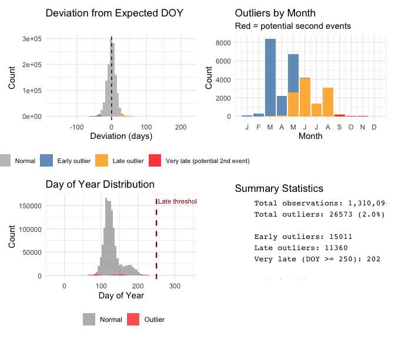

```r
# Overview of outlier patterns
pep_plot_outliers(outliers, type = "overview")
```

**What to look for:** - Which species have the most outliers? (Might indicate data quality issues) - Are outliers concentrated in certain phases? (Might indicate definition problems) - What’s the overall outlier rate? (Typical: 1-5% for well-curated data)

### 2. Seasonal Distribution

When in the year do outliers occur?

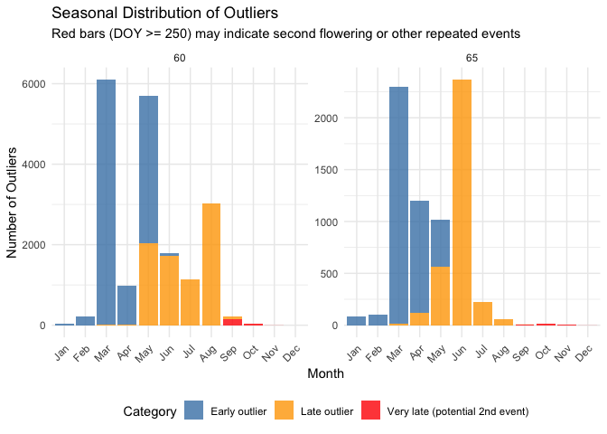

```r
# When do outliers occur in the year?
pep_plot_outliers(outliers, type = "seasonal")
```

**Interpretation guide:**

| Outlier Timing | Likely Explanation |
| --- | --- |
| Very early (DOY < 50) | Possible data errors (flowering in January/February unlikely for most species) |
| Somewhat early | Warm winters or Mediterranean locations |
| Somewhat late | Cool springs or high-altitude stations |
| Very late (DOY > 250) | Possible **second flowering** events - investigate! |

### 3. Detailed Context

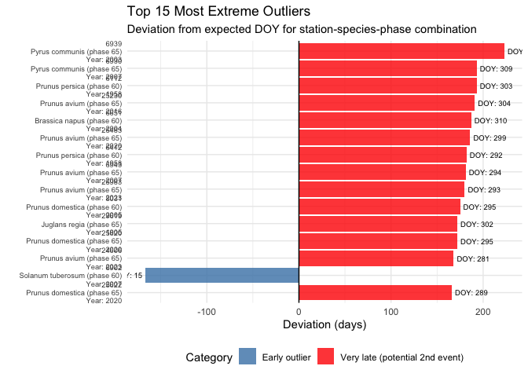

```r
# See outliers in context of all observations
pep_plot_outliers(outliers, type = "detail", n_top = 15)
```

### 4. Geographic Distribution

Where are outliers located?

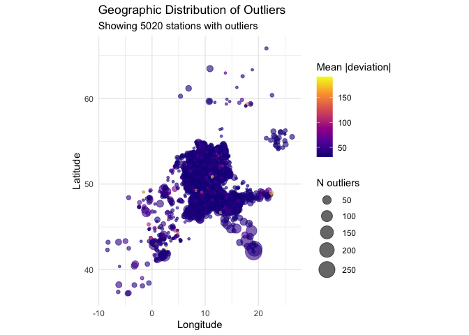

```r
# Where are outliers located?
pep_plot_outliers(outliers, type = "map")
```

**What to look for:** - Clustered outliers in one region? Might indicate local data quality issues - Outliers at network edges? Might be at environmental limits - Random scatter? Suggests individual observation errors

### 5. Model Diagnostic (for `gam_residual` / `mahalanobis`)

`type = "diagnostic"` produces a paper-ready 4-panel figure tailored to the detection method. For `gam_residual` the panels are classical GAM diagnostics — residuals vs fitted, Q-Q against Normal, |residual| vs altitude, and a per-station worst-case-residual map. For `mahalanobis` the panels switch automatically to MD-specific diagnostics: sorted MD with the chi-square threshold line, Q-Q of MD² against χ²_*p*, mean/max MD over time (exposes network-wide anomalous epochs), and the per-station worst-case MD map.

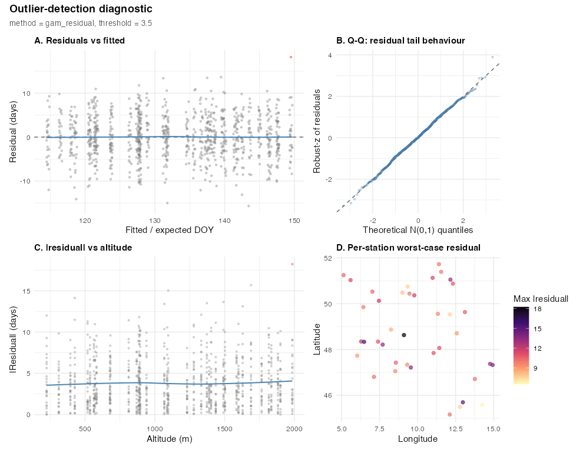

```r
# For gam_residual: classical model diagnostics
outliers_gam <- pep_flag_outliers(
  apple_flowering,
  by = c("genus", "species", "phase_id"),
  method = "gam_residual"
)
pep_plot_outliers(outliers_gam, type = "diagnostic")
```

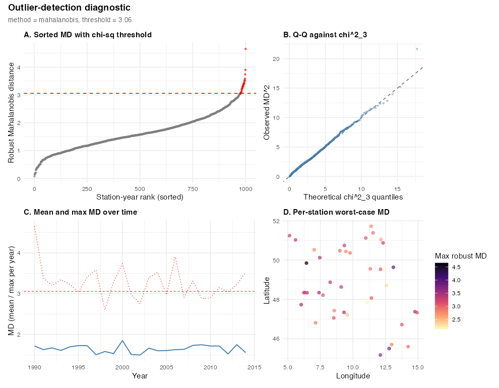

Mahalanobis-specific diagnostic on the same synthetic fixture. Panel A: sorted robust Mahalanobis distances across all station-years, with the $\sqrt{\chi^2_{0.975,\,3}} \approx 3.06$ threshold as a red dashed line; flagged points are red. Panel B: Q-Q of observed $\mathrm{MD}^2$ against $\chi^2_3$ — upper-tail departure identifies the outlier mass. Panel C: mean (blue) and max (red dotted) MD per year — the spike at year 2000 coincides with the injected anomaly. Panel D: per-station worst-case MD map.

```r
# For mahalanobis: MD-specific diagnostics
outliers_mahal <- pep_flag_outliers(
  apple,
  by = c("genus", "species"),
  method = "mahalanobis"
)
pep_plot_outliers(outliers_mahal, type = "diagnostic")
```

**What to look for:**

- **Residuals vs fitted (GAM)**: a level trend with no structure is ideal; a funnel or curve signals model misspecification, not outliers.
- **Q-Q (GAM)**: heavy-tailed deviations in the corners are the real outlier signal — light tails mean the threshold is picking up noise.
- **Sorted MD with threshold (Mahalanobis)**: the steep rise at the right-hand end is where flagged station-years sit; a long flat “knee” across the threshold means the threshold is arguably too loose or too strict.
- **Mean / max MD over time (Mahalanobis)**: spikes in the max line identify *years* in which many stations reported biologically inconsistent phase sequences — useful for correlating with known data-collection or instrumental events.

### 6. Phase-profile Plot (primary Mahalanobis figure)

The MD detector flags station-years whose *shape* across phases is atypical, even when each marginal DOY looks fine. `type = "profile"` plots the phase profile as parallel coordinates — one line per station-year, flagged ones in red, with the robust median profile overlaid in black as a reference:

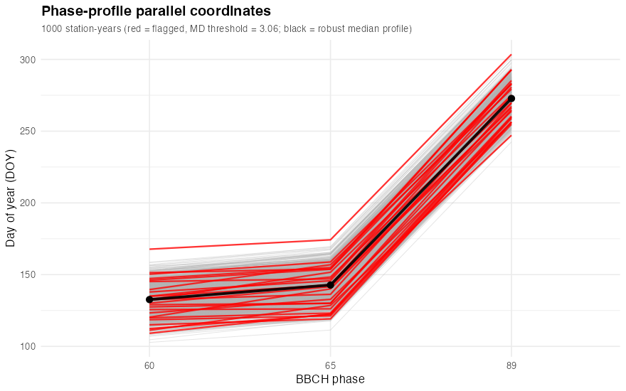

Phase-profile parallel-coordinates plot. Each line is one station-year; the grey envelope shows the natural variability of the network, the red lines are station-years flagged by the robust Mahalanobis detector, and the thick black line is the MCD robust per-phase median profile. Red lines that cross the phases at atypical angles — not just at unusual absolute DOYs — are the classic Mahalanobis flags.

```r
# Phase-profile parallel coordinates (primary Mahalanobis figure).
pep_plot_outliers(outliers_mahal, type = "profile")
```

**How to read it:**

- Every grey line is a “normal-looking” station-year; together they form the envelope of the robust ellipsoid.
- Red lines are flagged. Look where they bend oddly: a station-year whose BBCH 60 → 65 slope is much flatter or steeper than the reference is the classic MD flag.
- The black reference profile is the robust (MCD) per-phase median — the centre of the ellipsoid. Anything strongly parallel to this is safe; anything that crosses multiple phases at unusual angles is suspect.

# Part 2: Data Completeness

## Why Check Completeness?

**Data completeness** refers to how many years of observations exist for each station/phase combination. This matters because:

1. **Trend analysis requires continuous data**: Gaps can bias trend estimates
2. **Normals require representative coverage**: WMO recommends 24+ years in a 30-year period
3. **Missing data isn’t random**: Stations often drop out or are added systematically

### Visualizing Completeness Issues

```
Station A: ●●●●●●●●●●●●●●●●●●●●●●●●●●●●●●  <- 100% complete
           1990                      2020

Station B: ●●●●●●●●●●○○○○○○○○○○●●●●●●●●●●  <- Gap in middle
           1990                      2020

Station C: ○○○○○○○○○○○○○○○○○○○○●●●●●●●●●●  <- Only recent data
           1990                      2020

Station D: ●●●●●●●●●●●●●●●●●●●●○○○○○○○○○○  <- Discontinued
           1990                      2020
```

Different completeness patterns have different implications:

| Pattern | Implications for Analysis |
| --- | --- |
| Full coverage | Ideal - reliable trends and normals |
| Gap in middle | Careful - may miss important changes |
| Only recent | Cannot compare to historical period |
| Discontinued | Cannot assess recent changes |

## Assessing Completeness

```r
# Check completeness by station and phase
# Use year_range to focus on a specific period
completeness <- pep_completeness(
  pep = flowering,
  by = c("s_id", "phase_id"),
  year_range = c(1990, 2020)
)

print(completeness)
```

```
#> Phenological Data Completeness Assessment
#> --------------------------------------------------
#> Grouping by: s_id, phase_id
#> Year range: 1990-2020
#> Total groups: 8390
#> Mean completeness: 95.1%
#> Groups with >80% completeness: 7686 (91.6%)
#> --------------------------------------------------
#>
#>       s_id phase_id n_obs n_stations n_years year_min year_max year_span
#>     <fctr>    <int> <int>      <int>   <int>    <int>    <int>     <int>
#>  1:      1       60    33          1      10     1990     1999        10
#>  2:      1       65    25          1       8     1990     1998         9
#>  3:      3       60    30          1      17     1990     2006        17
#>  4:      3       65    27          1      16     1991     2006        16
#>  5:      4       60    62          1      26     1990     2015        26
#>  6:      4       65    55          1      26     1990     2015        26
#>  7:      5       60    10          1       6     1990     1995         6
#>  8:      5       65     7          1       4     1991     1994         4
#>  9:      9       60     6          1       3     1990     1992         3
#> 10:      9       65     4          1       3     1990     1992         3
#> 11:     11       60    16          1       7     1990     1996         7
#> 12:     11       65    15          1       7     1990     1996         7
#> 13:     13       60     3          1       3     1990     1995         6
#> 14:     13       65     4          1       4     1993     1998         6
#> 15:     15       60    27          1      10     1994     2012        19
#>     completeness_pct median_doy iqr_doy
#>                <num>      <num>   <num>
#>  1:            100.0      129.0    13.0
#>  2:             88.9      137.0    12.0
#>  3:            100.0      116.0    13.8
#>  4:            100.0      125.0     8.0
#>  5:            100.0      119.0    17.0
#>  6:            100.0      123.0    12.5
#>  7:            100.0      116.0    13.5
#>  8:            100.0      129.0     6.5
#>  9:            100.0      121.5    21.0
#> 10:            100.0      126.0    22.5
#> 11:            100.0      121.5    10.0
#> 12:            100.0      134.0     7.0
#> 13:             50.0      134.0    11.0
#> 14:             66.7      133.0     2.8
#> 15:             52.6      123.0    11.0
#>
#> ... and 8375 more rows
```

### Understanding Completeness Metrics

The function calculates several metrics:

[output not shown]

### Summary Statistics

```r
summary(completeness)
```

```
#> Phenological Data Completeness Summary
#> ==================================================
#>
#> Total groups: 8390
#> Total observations: 441,295
#> Total unique stations: 8,390
#>
#> Completeness Distribution:
#>   0-20%:   33 (  0.4%)
#>   20-40%:   99 (  1.2%)
#>   40-60%:  224 (  2.7%) *
#>   60-80%:  413 (  4.9%) *
#>   80-100%: 7621 ( 90.8%) ******************
#>
#> Year Coverage Statistics:
#>   Mean year span: 14.1 years
#>   Mean years with data: 13.2
#>   Earliest data: 1990
#>   Latest data: 2020
#>
#> Observation Statistics:
#>   Mean observations per group: 52.6
#>   Median observations per group: 38
#>   Max observations: 346
#>
#> Phenology Statistics:
#>   DOY range: 6 - 304
```

## Filtering by Completeness

Use completeness information to select stations appropriate for your analysis:

```r
# Get stations with good coverage (>= 70%)
good_coverage <- completeness[completeness_pct >= 70]
cat("Stations with >= 70% coverage:", nrow(good_coverage), "\n")
```

```
#> Stations with >= 70% coverage: 7893
```

```r
# Use these for trend analysis
good_stations <- unique(good_coverage$s_id)
flowering_complete <- flowering[s_id %in% good_stations]
cat("Observations from complete stations:", nrow(flowering_complete), "\n")
```

```
#> Observations from complete stations: 935551
```

### Completeness Thresholds for Different Analyses

| Analysis Type | Minimum Completeness | Reasoning |
| --- | --- | --- |
| Trend detection | 50% (15+ years) | Need enough points for trend fitting |
| Climate sensitivity | 60% | Need variability across climate conditions |
| 30-year normals | 80% (24+ years) | WMO standard requirement |
| Station comparison | Same time period | Avoid bias from different eras |

## Visualizing Completeness

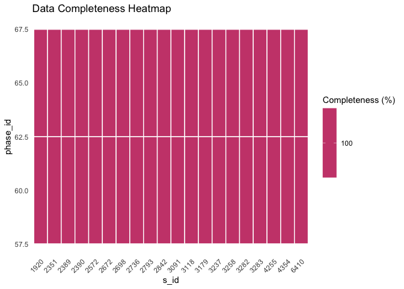

```r
plot(completeness)
```

# Part 3: Phase Presence Validation

## Why Check Phase Presence?

Before starting an analysis, it’s important to verify that your data contains the phenological phases you need. The `pep_check_phases()` function validates that expected BBCH phase codes are present in your data.

**Common questions this helps answer:**

- Does my dataset have flowering observations (phase 60)?
- Are flowering and fruit maturity phases both available for apple?
- Which phases are missing for my species of interest?

## Checking Phase Presence

```r
# Check if expected phases are present for apple
apple <- pep[species == "Malus domestica"]

phase_check <- pep_check_phases(
  pep = apple,
  expected = c(60, 65, 87)  # flowering, full flowering, fruit maturity
)

print(phase_check)
```

```
#> Phenological Phase Availability Check
#> ---------------------------------------------
#>
#> Expected phases: 60, 65, 87
#> Status: COMPLETE - all expected phases present
#>
#> Phases found:
#>   Phase   0: 1 observations [extra]
#>   Phase   7: 33 observations [extra]
#>   Phase  10: 1,394 observations [extra]
#>   Phase  11: 700 observations [extra]
#>   Phase  15: 159 observations [extra]
#>   Phase  57: 26 observations [extra]
#>   Phase  59: 25 observations [extra]
#>   Phase  60: 205,403 observations
#>   Phase  61: 1,055 observations [extra]
#>   Phase  63: 80 observations [extra]
#>   Phase  65: 175,706 observations
#>   Phase  67: 29 observations [extra]
#>   Phase  69: 170,323 observations [extra]
#>   Phase  81: 151 observations [extra]
#>   Phase  85: 93 observations [extra]
#>   Phase  87: 253,169 observations
#>   Phase  89: 17 observations [extra]
#>   Phase  91: 80 observations [extra]
#>   Phase  93: 617 observations [extra]
#>   Phase  95: 76,453 observations [extra]
#>   Phase  97: 2,470 observations [extra]
#>   Phase 100: 225 observations [extra]
#>   Phase 200: 3 observations [extra]
#>   Phase 201: 517 observations [extra]
#>   Phase 203: 1 observations [extra]
#>   Phase 205: 7,912 observations [extra]
#>   Phase 209: 2,358 observations [extra]
#>   Phase 213: 1 observations [extra]
#>   Phase 380: 208 observations [extra]
#>   Phase 381: 7 observations [extra]
#>   Phase 385: 95 observations [extra]
#>
#> Detailed coverage:
```

[output cut: 20 more lines]

```
#> 19:       93    617         76      55     1970     2024
#> 20:       95  76453       4120      78     1944     2024
#> 21:       97   2470        368      32     1966     2024
#> 22:      100    225         18      64     1951     2024
#> 23:      200      3          2       2     2016     2017
#> 24:      201    517         64      55     1970     2024
#> 25:      203      1          1       1     2016     2016
#> 26:      205   7912        779      79     1943     2025
#> 27:      209   2358        357      25     1966     2014
#> 28:      213      1          1       1     2012     2012
#> 29:      380    208         10      63     1961     2024
#> 30:      381      7          4       2     2023     2024
#> 31:      385     95         37      13     2013     2025
#>     phase_id  n_obs n_stations n_years year_min year_max
#>        <int>  <int>      <int>   <int>    <int>    <int>
```

### Understanding the Output

The function returns information about phase coverage:

| Output | What It Shows |
| --- | --- |
| `expected` | The phases you asked for |
| `present` | Which expected phases were found |
| `missing` | Which expected phases are absent |
| `complete` | TRUE if all expected phases are present |
| `n_obs` | Number of observations per phase |

## Checking Multiple Species

To check phase presence across multiple species at once:

```r
# Check phases for multiple species
multi_check <- pep_check_phases_multi(
  pep = pep,
  species_list = c("Malus domestica", "Vitis vinifera"),
  expected = c(60, 65, 87)
)

print(multi_check)
```

```
#> Multi-Species Phase Availability Check
#> ==================================================
#> Expected phases: 60, 65, 87
#>
#> Species with all phases: 2 / 2 (100%)
#> --------------------------------------------------
#>
#>            species complete n_expected n_present n_missing missing_phases
#>             <char>   <lgcl>      <int>     <int>     <int>         <char>
#> 1: Malus domestica     TRUE          3         3         0           <NA>
#> 2:  Vitis vinifera     TRUE          3         3         0           <NA>
#>    total_obs
#>        <int>
#> 1:    899311
#> 2:    146667
```

### Common Phases to Check

| Plant Type | Common Phases | BBCH Codes |
| --- | --- | --- |
| Cereals | Heading, Flowering, Harvest | 60, 65, 100 |
| Fruit trees | Flowering, Full flowering, Fruit maturity | 60, 65, 87 |
| Deciduous trees | Leaf unfolding, Flowering, Leaf fall | 11, 60, 95 |

# Part 4: Integrated Quality Workflow

## Putting It All Together

Here’s a recommended workflow for data quality assessment that combines all the tools covered in this vignette:

```r
# ══════════════════════════════════════════════════════════════════════════════
# STEP 1: Assess temporal completeness
# ══════════════════════════════════════════════════════════════════════════════
# Why: Incomplete stations can bias trend estimates and normals

completeness <- pep_completeness(flowering, by = c("s_id", "phase_id"))
good_stations <- completeness[completeness_pct >= 50, s_id]
fl_filtered <- flowering[s_id %in% good_stations]

cat("Kept", length(good_stations), "stations with >= 50% completeness\n")
```

```
#> Kept 15213 stations with >= 50% completeness
```

```r
# ══════════════════════════════════════════════════════════════════════════════
# STEP 2: Flag statistical outliers
# ══════════════════════════════════════════════════════════════════════════════
# Why: Identify observations that deviate from expected patterns

outliers_wf <- pep_flag_outliers(fl_filtered, method = "mad", threshold = 3)

cat("Flagged", sum(outliers_wf$is_outlier), "outliers",
    "(", round(100 * mean(outliers_wf$is_outlier), 1), "% )\n")
```

```
#> Flagged 20449 outliers ( 1.6 % )
```

```r
# ══════════════════════════════════════════════════════════════════════════════
# STEP 3: Make informed decisions about exclusion
# ══════════════════════════════════════════════════════════════════════════════
# Key principle: Document your decisions!

# Option A: Strict cleaning (for normals calculation)
fl_strict <- outliers_wf[is_outlier == FALSE]

# Option B: Moderate cleaning (keep moderate outliers)
fl_moderate <- outliers_wf[is_outlier == FALSE | abs(deviation) < 60]

cat("Strict cleaning keeps:", nrow(fl_strict), "obs\n")
```

```
#> Strict cleaning keeps: 1252610 obs
```

```r
cat("Moderate cleaning keeps:", nrow(fl_moderate), "obs\n")
```

```
#> Moderate cleaning keeps: 1272698 obs
```

```r
# ══════════════════════════════════════════════════════════════════════════════
# STEP 4: Proceed with analysis on cleaned data
# ══════════════════════════════════════════════════════════════════════════════

normals <- pheno_normals(fl_moderate, period = 1991:2020, min_years = 5)
```

```
#> Note: 44 group(s) have fewer than 5 years of data and return NA values.
```

```r
cat("Normals calculated for", sum(!is.na(normals$mean_doy)), "groups\n")
```

```
#> Normals calculated for 202 groups
```

## Documentation Template

When publishing research, document your quality control decisions:

```
Data Quality Control:
1. Completeness filtering: Excluded stations with < 50% temporal coverage
   (reduced dataset from N to M stations)

2. Outlier detection: Used MAD method with threshold = 3
   (flagged X observations as outliers, Y% of total)

3. Outlier disposition:
   - Excluded: Z observations with deviations > 60 days (likely errors)
   - Retained: W observations identified as abnormal events (e.g., second flowering)

4. Phase validation: Checked for sequence violations in [species list]
   (identified V cases for manual review)
```

# Best Practices Summary

## For Outlier Detection

1. **Use robust methods**: MAD or IQR methods handle multiple outliers better than z-scores. The MAD method is generally recommended.
2. **Check seasonally**: Late-season outliers (DOY > 250) may be biologically meaningful events (e.g. second flowering) rather than errors.
3. **Verify extremes**: For observations with very large deviations (> 60 days), try to check original data sources or contact data providers.
4. **Document decisions**: Record which outliers you exclude and why. This is essential for reproducibility and peer review.
5. **Don’t delete automatically**: Human judgment is needed to distinguish errors from genuine unusual events.

## For Abnormal Event Detection

1. **Consider species biology**: Some species (e.g., certain Rosaceae) are more prone to second flowering than others.
2. **Check geographic patterns**: If multiple nearby stations report late events in the same year, this suggests a real regional phenomenon.
3. **Look at weather context**: Link abnormal events to weather extremes - drought is a common trigger.
4. **Distinguish from errors**: Very isolated observations (single station, single year) need verification before treating them as e.g. second flowering.
5. **Keep for separate analysis**: Abnormal phenological events are scientifically interesting (proof of climate change) - don’t just delete them!

## For Completeness Assessment

1. **Set appropriate thresholds**: Use 80%+ coverage for calculating normals, 50%+ for trend analysis.
2. **Consider gap patterns**: Many small gaps are usually better than one long gap that might coincide with important climate changes.
3. **Check temporal bias**: Ensure you’re not comparing stations with data only from early periods to stations with only recent data.
4. **Document station selection**: Report how many stations met your completeness criteria and how this affected your sample.

## For Phase Presence Checking

1. **Check early**: Run `pep_check_phases()` at the start of your analysis to verify required phases are available in your data.
2. **Know required phases**: Different analyses need different phases - know which BBCH codes you need before starting.
3. **Check across species**: Use `pep_check_phases_multi()` to verify data availability for all species you plan to analyze.

## Summary

This vignette covered data quality tools for phenological analysis:

[output not shown]

### Key Take-Home Messages

1. **Data quality assessment is not optional** - it’s a critical step that affects the validity of all downstream analyses.
2. **Not all outliers are errors** - some represent genuine biological phenomena like second flowering that deserve further study.
3. **Document your decisions** - quality control choices should be transparent and reproducible.
4. **Use robust methods** - the MAD method is recommended for phenological data because it handles multiple outliers well.
5. **Visual inspection matters** - plots often reveal patterns that summary statistics miss.

## Next Steps

Explore the other vignettes for complementary analyses:

- **Getting Started**: Data access, the `pep` class, and basic exploration

```r
vignette("getting-started", package = "pep725")
```

- **Phenological Analysis**: Normals, anomalies, quality grading, and trends

```r
vignette("phenological-analysis", package = "pep725")
```

- **Spatial Phenological Patterns**: Gradients, synchrony, and mapping

```r
vignette("spatial-patterns", package = "pep725")
```

[^1]: University of Applied Sciences Northwestern Switzerland (FHNW)
[^2]: Swiss Federal Institute for Forest, Snow and Landscape Research (WSL)